# TCGA pan-cancer analysis

Lena Savin

This analysis is focused on the TCGA clinical Data from patients in all projects .  
The data was downloaded from the TCGA using the TCGAbiolinks library.  
My MSc project is analysis of all the RNA-seq data on the TCGA and therefore analysis of the clinical metadata will give my project a bigger and wider picture of the results.

### Import and primary clean

uploading the necessary libraries.

```r
library(dplyr)
library(skimr)
library(ggplot2)
library(caret)
library(ROCR)
library(psych)
```

My dataset includes all TCGA clinical data. the data was downloaded directly from the tcga using TCGAbiolinks package and saved into a csv file “clinical_data_TCGA.csv” attached.

```r
library(TCGAbiolinks)
dataset_list <- as.factor(grep("^TCGA-",
                               getGDCprojects()$project_id, value = TRUE))
for (dataset in dataset_list) {
  print(dataset)
  data <- GDCquery_clinic(project = dataset, type = "clinical")
  value <- assign(paste(dataset, "clinical", sep = "_"), data)
}
```

Merging them- my final Data set for work is clinical_data_TCGA

```r
list <- Filter(function(x) is(x, "data.frame"), mget(ls()))
clinical_data_TCGA <- bind_rows(list)
write.csv(clinical_data_TCGA, "clinical_data_TCGA.csv", na = "NA")
```

Reading the data into a data frame, where na is all the places where there is a missing value, space or explicitly “NA”.

```r
clinical_data_TCGA <- read.csv("clinical_data_TCGA.csv",
                               stringsAsFactors = T, na.strings=c(""," ","NA"))
skim(clinical_data_TCGA)
```

Data summary

| Name | clinical_data_TCGA |
| --- | --- |
| Number of rows | 12139 |
| Number of columns | 159 |
| _______________________ |  |
| Column type frequency: |  |
| factor | 50 |
| logical | 93 |
| numeric | 16 |
| ________________________ |  |
| Group variables | None |

**Variable type: factor**

| skim_variable | n_missing | complete_rate | ordered | n_unique | top_counts |
| --- | --- | --- | --- | --- | --- |
| submitter_id | 0 | 1.00 | FALSE | 11315 | TCG: 3, TCG: 3, TCG: 3, TCG: 3 |
| tissue_or_organ_of_origin | 148 | 0.99 | FALSE | 139 | Bre: 1088, Kid: 943, Bla: 711, Bra: 653 |
| icd_10_code | 352 | 0.97 | FALSE | 167 | C50: 1088, C67: 711, C64: 652, C71: 652 |
| state | 148 | 0.99 | FALSE | 1 | rel: 11991 |
| prior_malignancy | 148 | 0.99 | FALSE | 3 | no: 9698, yes: 1147, not: 1146 |
| last_known_disease_status | 148 | 0.99 | FALSE | 1 | not: 11991 |
| created_datetime | 12132 | 0.00 | FALSE | 7 | 201: 1, 201: 1, 201: 1, 201: 1 |
| ajcc_pathologic_stage | 4448 | 0.63 | FALSE | 19 | Sta: 1281, Sta: 972, Sta: 860, Sta: 804 |
| ajcc_staging_system_edition | 4924 | 0.59 | FALSE | 7 | 7th: 4115, 6th: 2549, 5th: 430, 4th: 87 |
| tumor_grade | 148 | 0.99 | FALSE | 1 | not: 11991 |
| tumor_stage | 148 | 0.99 | FALSE | 20 | not: 4210, sta: 1290, sta: 991, sta: 904 |
| progression_or_recurrence | 148 | 0.99 | FALSE | 1 | not: 11991 |
| classification_of_tumor | 148 | 0.99 | FALSE | 1 | not: 11991 |
| ajcc_pathologic_m | 4352 | 0.64 | FALSE | 7 | M0: 5430, MX: 1975, M1: 325, M1a: 24 |
| prior_treatment | 148 | 0.99 | FALSE | 3 | No: 11778, Yes: 205, Not: 8 |
| morphology | 148 | 0.99 | FALSE | 137 | 814: 1615, 807: 1182, 812: 1029, 850: 937 |
| site_of_resection_or_biopsy | 148 | 0.99 | FALSE | 158 | Bre: 1088, Kid: 943, Bla: 711, Bra: 655 |
| synchronous_malignancy | 148 | 0.99 | FALSE | 3 | No: 9801, Not: 2145, Yes: 45 |
| diagnosis_id | 148 | 0.99 | FALSE | 11167 | 001: 3, 007: 3, 010: 3, 016: 3 |
| ajcc_pathologic_n | 3486 | 0.71 | FALSE | 18 | N0: 4303, N1: 1291, NX: 1165, N2: 634 |
| ajcc_pathologic_t | 3490 | 0.71 | FALSE | 26 | T2: 2003, T3: 1658, T1: 685, T3a: 647 |
| updated_datetime | 148 | 0.99 | FALSE | 237 | 201: 150, 201: 150, 201: 150, 201: 150 |
| primary_diagnosis | 148 | 0.99 | FALSE | 136 | Ade: 1615, Squ: 1182, Tra: 1029, Inf: 937 |
| ajcc_clinical_t | 10217 | 0.16 | FALSE | 18 | T2: 523, T3: 228, T4a: 206, T1: 176 |
| exposure_id | 148 | 0.99 | FALSE | 11167 | 004: 3, 023: 3, 030: 3, 045: 3 |
| alcohol_history | 148 | 0.99 | FALSE | 3 | Not: 11125, Yes: 583, No: 283 |
| demographic_id | 148 | 0.99 | FALSE | 11167 | 009: 3, 011: 3, 012: 3, 014: 3 |
| race | 148 | 0.99 | FALSE | 6 | whi: 9111, not: 1035, bla: 1031, asi: 773 |
| ethnicity | 148 | 0.99 | FALSE | 3 | not: 9154, not: 2435, his: 402 |
| vital_status | 148 | 0.99 | FALSE | 3 | Ali: 7968, Dea: 4005, Not: 18 |
| gender | 148 | 0.99 | FALSE | 3 | fem: 6033, mal: 5954, not: 4 |
| treatments_pharmaceutical_treatment_id | 148 | 0.99 | FALSE | 11167 | 004: 3, 00a: 3, 012: 3, 017: 3 |
| treatments_pharmaceutical_treatment_or_therapy | 148 | 0.99 | FALSE | 3 | no: 5660, yes: 4963, not: 1368 |
| treatments_pharmaceutical_treatment_type | 148 | 0.99 | FALSE | 1 | Pha: 11991 |
| treatments_radiation_treatment_id | 148 | 0.99 | FALSE | 11167 | 006: 3, 00e: 3, 017: 3, 023: 3 |
| treatments_radiation_treatment_or_therapy | 148 | 0.99 | FALSE | 3 | no: 7008, yes: 3693, not: 1290 |
| treatments_radiation_treatment_type | 148 | 0.99 | FALSE | 1 | Rad: 11991 |
| bcr_patient_barcode | 0 | 1.00 | FALSE | 11315 | TCG: 3, TCG: 3, TCG: 3, TCG: 3 |
| disease | 0 | 1.00 | FALSE | 33 | BLC: 1236, BRC: 1098, GBM: 617, OV: 608 |
| ajcc_clinical_m | 10402 | 0.14 | FALSE | 6 | M0: 1556, MX: 119, M1: 47, M1a: 7 |
| figo_stage | 10652 | 0.12 | FALSE | 23 | Sta: 449, Sta: 194, Sta: 185, Sta: 94 |
| primary_gleason_grade | 11639 | 0.04 | FALSE | 4 | Pat: 250, Pat: 200, Pat: 49, Pat: 1 |
| ann_arbor_extranodal_involvement | 12093 | 0.00 | FALSE | 2 | No: 25, Yes: 21 |
| ajcc_clinical_stage | 11156 | 0.08 | FALSE | 16 | Sta: 271, Sta: 174, Sta: 146, Sta: 125 |
| masaoka_stage | 12017 | 0.01 | FALSE | 6 | Sta: 41, Sta: 38, Sta: 20, Sta: 15 |
| ajcc_clinical_n | 11139 | 0.08 | FALSE | 8 | N0: 556, N1: 153, NX: 104, N2b: 85 |
| ann_arbor_b_symptoms | 12093 | 0.00 | FALSE | 2 | No: 35, Yes: 11 |
| ann_arbor_clinical_stage | 12097 | 0.00 | FALSE | 4 | Sta: 17, Sta: 12, Sta: 8, Sta: 5 |
| igcccg_stage | 12096 | 0.00 | FALSE | 3 | Goo: 32, Int: 9, Poo: 2 |
| secondary_gleason_grade | 11639 | 0.04 | FALSE | 3 | Pat: 238, Pat: 152, Pat: 110 |

**Variable type: logical**

| skim_variable | n_missing | complete_rate | mean | count |
| --- | --- | --- | --- | --- |
| days_to_recurrence | 12139 | 0 | NaN | : |
| days_to_last_known_disease_status | 12139 | 0 | NaN | : |
| alcohol_intensity | 12139 | 0 | NaN | : |
| treatments_pharmaceutical_therapeutic_agents | 12139 | 0 | NaN | : |
| treatments_pharmaceutical_treatment_intent_type | 12139 | 0 | NaN | : |
| treatments_pharmaceutical_treatment_outcome | 12139 | 0 | NaN | : |
| treatments_pharmaceutical_initial_disease_status | 12139 | 0 | NaN | : |
| treatments_pharmaceutical_days_to_treatment_start | 12139 | 0 | NaN | : |
| treatments_pharmaceutical_regimen_or_line_of_therapy | 12139 | 0 | NaN | : |
| treatments_pharmaceutical_days_to_treatment_end | 12139 | 0 | NaN | : |
| treatments_pharmaceutical_treatment_effect | 12139 | 0 | NaN | : |
| treatments_pharmaceutical_treatment_anatomic_site | 12139 | 0 | NaN | : |
| treatments_radiation_therapeutic_agents | 12139 | 0 | NaN | : |
| treatments_radiation_treatment_intent_type | 12139 | 0 | NaN | : |
| treatments_radiation_treatment_outcome | 12139 | 0 | NaN | : |
| treatments_radiation_initial_disease_status | 12139 | 0 | NaN | : |
| treatments_radiation_days_to_treatment_start | 12139 | 0 | NaN | : |
| treatments_radiation_regimen_or_line_of_therapy | 12139 | 0 | NaN | : |
| treatments_radiation_days_to_treatment_end | 12139 | 0 | NaN | : |
| treatments_radiation_treatment_effect | 12139 | 0 | NaN | : |
| treatments_radiation_treatment_anatomic_site | 12139 | 0 | NaN | : |
| NA. | 12139 | 0 | NaN | : |
| best_overall_response | 12139 | 0 | NaN | : |
| gastric_esophageal_junction_involvement | 12139 | 0 | NaN | : |
| cog_renal_stage | 12139 | 0 | NaN | : |
| tumor_confined_to_organ_of_origin | 12139 | 0 | NaN | : |
| micropapillary_features | 12139 | 0 | NaN | : |
| cog_liver_stage | 12139 | 0 | NaN | : |
| iss_stage | 12139 | 0 | NaN | : |
| method_of_diagnosis | 12139 | 0 | NaN | : |

[output cut: 63 more lines]

**Variable type: numeric**

| skim_variable | n_missing | complete_rate | mean | sd | p0 | p25 | p50 | p75 | p100 | hist |
| --- | --- | --- | --- | --- | --- | --- | --- | --- | --- | --- |
| X | 0 | 1.00 | 6070.00 | 3504.37 | 1.00 | 3035.50 | 6070.00 | 9104.50 | 12139.00 | ▇▇▇▇▇ |
| year_of_diagnosis | 317 | 0.97 | 2008.17 | 4.26 | 1978.00 | 2006.00 | 2009.00 | 2011.00 | 2013.00 | ▁▁▁▂▇ |
| days_to_last_follow_up | 2400 | 0.80 | 1022.95 | 1040.47 | -64.00 | 370.00 | 700.00 | 1366.00 | 11252.00 | ▇▁▁▁▁ |
| days_to_diagnosis | 276 | 0.98 | 0.00 | 0.00 | 0.00 | 0.00 | 0.00 | 0.00 | 0.00 | ▁▁▇▁▁ |
| age_at_diagnosis | 275 | 0.98 | 21990.24 | 5247.62 | 3982.00 | 18751.50 | 22418.00 | 25812.00 | 32872.00 | ▁▂▆▇▃ |
| height | 8676 | 0.29 | 167.98 | 10.93 | 61.00 | 160.00 | 168.00 | 175.00 | 197.00 | ▁▁▁▇▇ |
| years_smoked | 11499 | 0.05 | 33.65 | 14.04 | 2.00 | 22.75 | 35.00 | 44.00 | 65.00 | ▂▆▆▇▂ |
| bmi | 8694 | 0.28 | 28.56 | 11.95 | 11.74 | 23.44 | 26.78 | 31.62 | 414.89 | ▇▁▁▁▁ |
| weight | 8589 | 0.29 | 80.21 | 22.71 | 31.00 | 64.00 | 77.00 | 92.00 | 292.00 | ▇▅▁▁▁ |
| pack_years_smoked | 10021 | 0.17 | 41.25 | 38.98 | 0.02 | 20.00 | 36.00 | 52.00 | 730.00 | ▇▁▁▁▁ |
| cigarettes_per_day | 10021 | 0.17 | 2.26 | 2.14 | 0.00 | 1.10 | 1.97 | 2.85 | 40.00 | ▇▁▁▁▁ |
| days_to_death | 8177 | 0.33 | 816.36 | 917.42 | 0.00 | 262.00 | 530.00 | 1038.75 | 10870.00 | ▇▁▁▁▁ |
| days_to_birth | 275 | 0.98 | -21990.24 | 5247.62 | -32872.00 | -25812.00 | -22418.00 | -18751.50 | -3982.00 | ▃▇▆▂▁ |
| year_of_birth | 357 | 0.97 | 1948.53 | 14.82 | 1902.00 | 1938.00 | 1948.00 | 1958.00 | 1997.00 | ▁▅▇▃▁ |
| year_of_death | 9228 | 0.24 | 2006.41 | 4.40 | 1990.00 | 2004.00 | 2007.00 | 2010.00 | 2014.00 | ▁▁▃▇▅ |
| age_at_index | 205 | 0.98 | 59.72 | 14.37 | 10.00 | 51.00 | 61.00 | 70.00 | 90.00 | ▁▂▆▇▃ |

Leaving in the data frame only the features with less than 1000 NA’s - these features have a lot of the data missing, therefore do not contribute enough to the dataset.  
Removing all rows with NA’s to avoid missing values issues.

```r
clinical_data_TCGA <- select_if(clinical_data_TCGA, funs(sum(is.na(.)) <= 1000))
clinical_data_TCGA <- as.data.frame(unclass(clinical_data_TCGA))
clinical_data_TCGA <- na.omit(clinical_data_TCGA)
```

Taking a look at the variables left. there are 39 features left. next i will use manual feature selection to remove redundant or unproductive features.

```r
str(clinical_data_TCGA)
```

```
## 'data.frame':    11512 obs. of  39 variables:
##  $ X                                             : int  1 2 3 4 5 6 7 8 9 10 ...
##  $ submitter_id                                  : Factor w/ 11315 levels "TCGA-01-0628",..: 5598 10995 5600 4986 9071 6537 8484 7949 5188 7000 ...
##  $ tissue_or_organ_of_origin                     : Factor w/ 139 levels "Adrenal gland, NOS",..: 9 9 9 9 101 38 130 4 9 9 ...
##  $ icd_10_code                                   : Factor w/ 167 levels "C00.9","C01",..: 133 133 133 133 130 127 126 129 133 133 ...
##  $ state                                         : Factor w/ 1 level "released": 1 1 1 1 1 1 1 1 1 1 ...
##  $ prior_malignancy                              : Factor w/ 3 levels "no","not reported",..: 1 1 1 3 1 1 1 1 1 1 ...
##  $ last_known_disease_status                     : Factor w/ 1 level "not reported": 1 1 1 1 1 1 1 1 1 1 ...
##  $ year_of_diagnosis                             : int  2005 2007 2010 2008 2012 2008 2011 2009 2011 2012 ...
##  $ tumor_grade                                   : Factor w/ 1 level "not reported": 1 1 1 1 1 1 1 1 1 1 ...
##  $ tumor_stage                                   : Factor w/ 20 levels "i/ii nos","is",..: 12 12 16 16 12 8 8 16 8 8 ...
##  $ progression_or_recurrence                     : Factor w/ 1 level "not reported": 1 1 1 1 1 1 1 1 1 1 ...
##  $ classification_of_tumor                       : Factor w/ 1 level "not reported": 1 1 1 1 1 1 1 1 1 1 ...
##  $ days_to_diagnosis                             : int  0 0 0 0 0 0 0 0 0 0 ...
##  $ prior_treatment                               : Factor w/ 3 levels "No","Not Reported",..: 1 1 1 1 1 1 1 1 1 1 ...
```

[output cut: 27 more lines]

### Feature selection

The id columns give no additive information, and are keys to other datasets available on the GDC, for example the diagnosis_id is the patients id in the diagnosis dataset (description: https://docs.gdc.cancer.gov/Data_Dictionary/viewer/#?view=table-definition-view&id=diagnosis)  
days_to_birth gives the same information as age at index. other variables removed have only one value.

```r
clinical_data_TCGA <- dplyr::select(clinical_data_TCGA, -updated_datetime,
                                    -icd_10_code, -progression_or_recurrence ,
                      -tumor_grade, -days_to_diagnosis, -classification_of_tumor,
                      -state, -last_known_disease_status, -diagnosis_id,
                      -exposure_id, -demographic_id,
                      -treatments_pharmaceutical_treatment_id,
                      -treatments_pharmaceutical_treatment_type,
                      -bcr_patient_barcode,
                      -treatments_radiation_treatment_id,
                      -treatments_radiation_treatment_type, -alcohol_history,
                      -days_to_birth, -submitter_id, -X)
str(clinical_data_TCGA)
```

```
## 'data.frame':    11512 obs. of  19 variables:
##  $ tissue_or_organ_of_origin                     : Factor w/ 139 levels "Adrenal gland, NOS",..: 9 9 9 9 101 38 130 4 9 9 ...
##  $ prior_malignancy                              : Factor w/ 3 levels "no","not reported",..: 1 1 1 3 1 1 1 1 1 1 ...
##  $ year_of_diagnosis                             : int  2005 2007 2010 2008 2012 2008 2011 2009 2011 2012 ...
##  $ tumor_stage                                   : Factor w/ 20 levels "i/ii nos","is",..: 12 12 16 16 12 8 8 16 8 8 ...
##  $ prior_treatment                               : Factor w/ 3 levels "No","Not Reported",..: 1 1 1 1 1 1 1 1 1 1 ...
##  $ morphology                                    : Factor w/ 137 levels "8010/3","8013/3",..: 15 14 14 14 14 14 14 14 15 14 ...
##  $ site_of_resection_or_biopsy                   : Factor w/ 158 levels "Abdomen, NOS",..: 10 10 10 10 111 39 147 5 10 10 ...
##  $ synchronous_malignancy                        : Factor w/ 3 levels "No","Not Reported",..: 1 1 1 2 1 1 1 1 1 1 ...
##  $ age_at_diagnosis                              : int  21927 28302 30674 28428 24614 30089 24681 28451 27458 28714 ...
##  $ primary_diagnosis                             : Factor w/ 136 levels "Abdominal fibromatosis",..: 93 133 133 133 133 133 133 133 93 133 ...
##  $ race                                          : Factor w/ 6 levels "american indian or alaska native",..: 6 6 6 5 6 2 6 6 2 2 ...
##  $ ethnicity                                     : Factor w/ 3 levels "hispanic or latino",..: 2 2 2 3 2 2 2 2 2 2 ...
##  $ vital_status                                  : Factor w/ 3 levels "Alive","Dead",..: 2 2 2 2 2 1 2 2 1 1 ...
##  $ gender                                        : Factor w/ 3 levels "female","male",..: 2 1 2 2 1 1 2 1 2 1 ...
##  $ year_of_birth                                 : int  1945 1930 1927 1931 1945 1926 1944 1932 1936 1934 ...
##  $ age_at_index                                  : int  60 77 83 77 67 82 67 77 75 78 ...
##  $ treatments_pharmaceutical_treatment_or_therapy: Factor w/ 3 levels "no","not reported",..: 1 1 1 2 1 1 3 3 1 2 ...
##  $ treatments_radiation_treatment_or_therapy     : Factor w/ 3 levels "no","not reported",..: 1 1 1 2 1 1 1 3 3 1 ...
##  $ disease                                       : Factor w/ 33 levels "ACC","BLCA","BRCA",..: 2 2 2 2 2 2 2 2 2 2 ...
```

Randomizing the data to avoid incline or specific grous only in training or only in test sets.

```r
set.seed(120)
clinical_data_TCGA <- clinical_data_TCGA[sample(1:nrow(clinical_data_TCGA)),]
```

### Visualisation and cleaning

Plotting the distribution of the categorical features to detect patterns and get to know the data better.

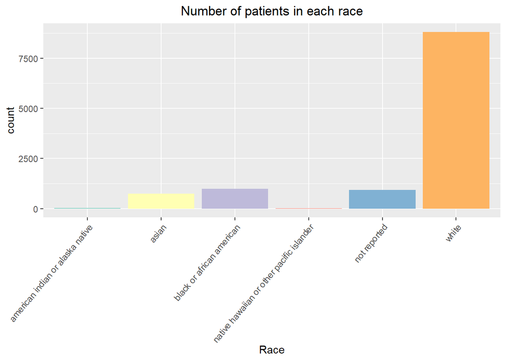

```r
library(RColorBrewer)
nb.cols <- 33
mycolors <- colorRampPalette(brewer.pal(33, "Set3"))(nb.cols)

ggplot(clinical_data_TCGA, aes(x=as.factor(race), fill=as.factor(race))) +
  geom_bar() + labs(title="Number of patients in each race", x = "Race") +
  theme(axis.text.x =element_text(angle = 50, hjust = 1),
        plot.title = element_text(hjust = 0.5), legend.position = "none") +
  scale_fill_brewer(palette = "Set3")
```

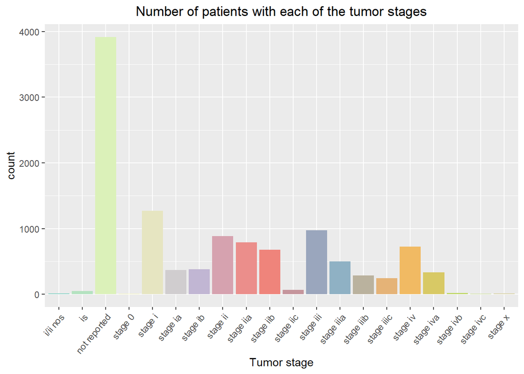

```r
ggplot(clinical_data_TCGA, aes(x=as.factor(tumor_stage),
                               fill=as.factor(tumor_stage))) + geom_bar() +
  labs(title="Number of patients with each of the tumor stages",
       x = "Tumor stage") +
theme(axis.text.x =element_text(angle = 50, hjust = 1),
      plot.title = element_text(hjust = 0.5), legend.position = "none") +
  scale_fill_manual(values = mycolors)
```

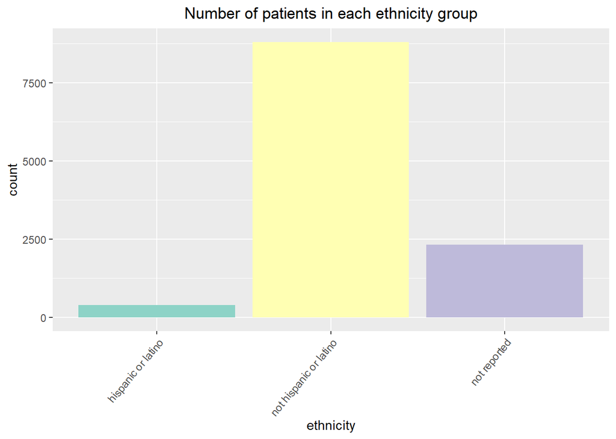

```r
ggplot(clinical_data_TCGA, aes(x=as.factor(ethnicity),
                               fill=as.factor(ethnicity))) + geom_bar() +
  labs(title="Number of patients in each ethnicity group", x = "ethnicity") +
  theme(axis.text.x =element_text(angle = 50, hjust = 1),
        plot.title = element_text(hjust = 0.5), legend.position = "none") +
  scale_fill_brewer(palette = "Set3")
```

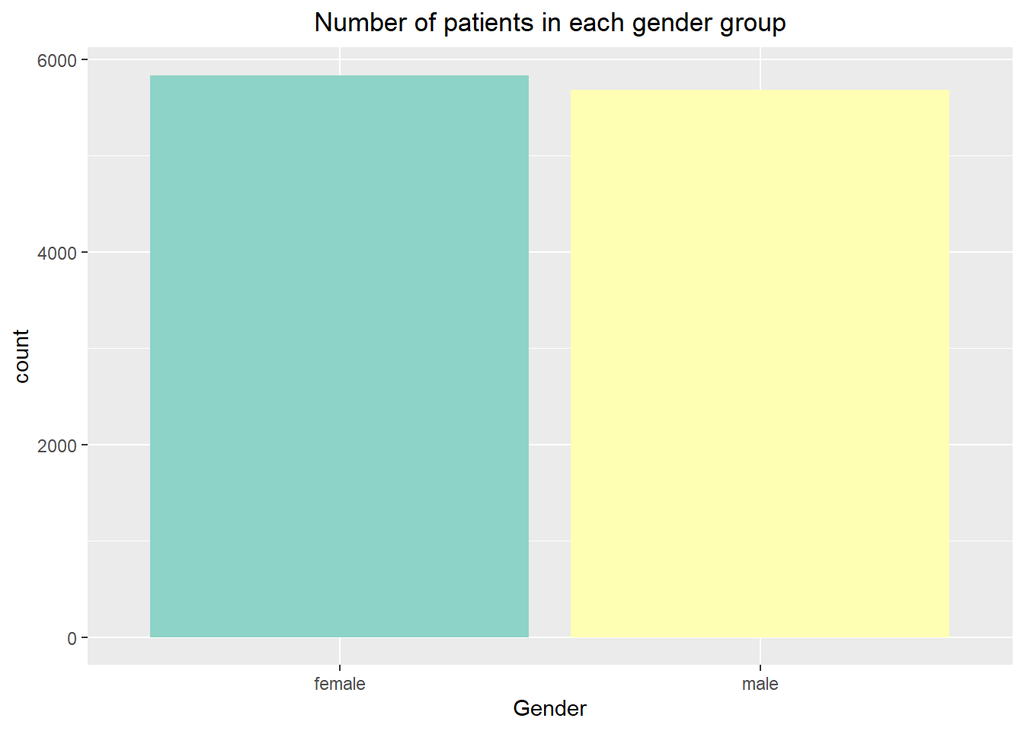

```r
ggplot(clinical_data_TCGA, aes(x=as.factor(gender),
                               fill=as.factor(gender))) + geom_bar() +
  labs(title="Number of patients in each gender group", x = "Gender") +
  theme( plot.title = element_text(hjust = 0.5), legend.position = "none") +
  scale_fill_brewer(palette = "Set3")
```

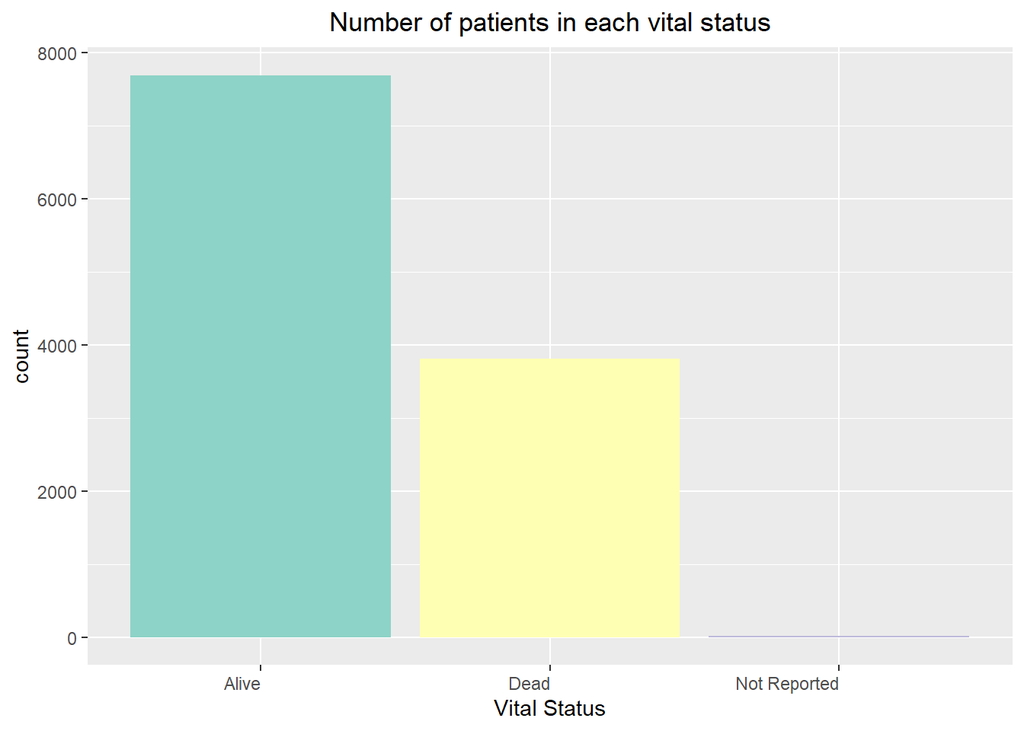

```r
ggplot(clinical_data_TCGA, aes(x=as.factor(vital_status),
                               fill=as.factor(vital_status))) + geom_bar() +
  labs(title="Number of patients in each vital status", x = "Vital Status") +
  theme(axis.text.x =element_text( hjust = 1),
        plot.title = element_text(hjust = 0.5), legend.position = "none") +
  scale_fill_brewer(palette = "Set3")
```

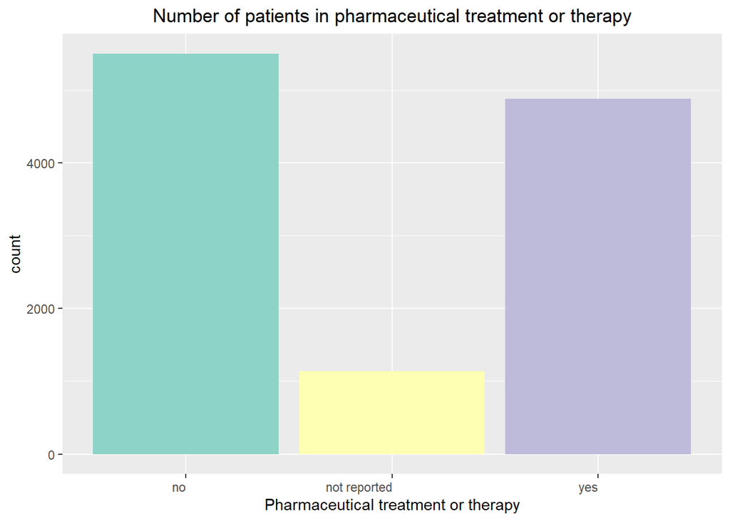

```r
ggplot(clinical_data_TCGA,
       aes(x=as.factor(treatments_pharmaceutical_treatment_or_therapy),
           fill=as.factor(treatments_pharmaceutical_treatment_or_therapy))) +
  geom_bar() +
  labs(title="Number of patients in pharmaceutical treatment or therapy",
       x = "Pharmaceutical treatment or therapy") +
  theme(axis.text.x =element_text( hjust = 1),
        plot.title = element_text(hjust = 0.5), legend.position = "none") +
  scale_fill_brewer(palette = "Set3")
```

To make these columns more informative, as i saw in the graphs above, the majority of the data is distributed in these two options. therefore i will change the “race” feature into white and not white(first plot), and the ethnicity (third plot) to “hispanic or latino” and “not hispanic or latino”.

```r
#change race to white and not white
clinical_data_TCGA$race <-
  ifelse(clinical_data_TCGA$race == "white", 1, 0)

#change ethnicity to hispanic or latino and not hispanic or latino
clinical_data_TCGA$hispanic_or_latino <-
  ifelse(clinical_data_TCGA$ethnicity == "not hispanic or latino", 0, 1)
clinical_data_TCGA <- clinical_data_TCGA %>% dplyr::select(-ethnicity)
```

Looking at features left for modeling and describing them:

```r
colnames(clinical_data_TCGA)
```

```
##  [1] "tissue_or_organ_of_origin"
##  [2] "prior_malignancy"
##  [3] "year_of_diagnosis"
##  [4] "tumor_stage"
##  [5] "prior_treatment"
##  [6] "morphology"
##  [7] "site_of_resection_or_biopsy"
##  [8] "synchronous_malignancy"
##  [9] "age_at_diagnosis"
## [10] "primary_diagnosis"
## [11] "race"
## [12] "vital_status"
## [13] "gender"
## [14] "year_of_birth"
## [15] "age_at_index"
## [16] "treatments_pharmaceutical_treatment_or_therapy"
## [17] "treatments_radiation_treatment_or_therapy"
## [18] "disease"
## [19] "hispanic_or_latino"
```

*tissue_or_organ_of_origin* - the anatomic site of origin, of the patient’s malignant disease.  
*prior_malignancy* - yes/no if a patient had a prior malignancy.  
*year_of_diagnosis* - Numeric value to represent the year of an individual’s initial pathologic diagnosis of cancer.  
*Tumor stage* - Stage group determined from clinical information on the tumor (T), regional node (N) and metastases (M) and by grouping cases with similar prognosis for cancer. *prior_treatment* - yes/no if a patient had a prior cancer treatment.  
*morphology* - enum where each represents the biopsy morphology.  
*site_of_resection_or_biopsy* - organ of resection or biopsy.  
*synchronous_malignancy* - A yes/no/unknown indicator used to describe whether the patient had an additional malignant diagnosis at the same time the tumor used for sequencing was diagnosed.  
*age_at_diagnosis* - Age at the time of diagnosis expressed in number of days since birth.  
*primary_diagnosis* - The patient’s histologic diagnosis, as described by the World Health Organization’s (WHO) International Classification of Diseases for Oncology (ICD-O).  
*race* - If the patient is white or not.  
*vital_status* - dead or alive.  
*gender* - patients gender.  
*year_of_birth* - Numeric value to represent the calendar year in which an individual was born.  
*age_at_index* - The patient’s age (in years) on the reference or anchor date date used during date obfuscation.  
*treatments_pharmaceutical_treatment_or_therapy* - yes/no if a patient had pharmaceutical treatment or therapy.  
*treatments_radiation_treatment_or_therapy* - yes/no if a patient had radiation or therapy.  
*disease* - project name.  
*hispanic_or_latino* - If the patient is hispanic or latino.

Turning age in days to years scale to create a identical scale for visualization with all other numerical features which are in years.

```r
clinical_data_TCGA$age_at_diagnosis <-
  clinical_data_TCGA$age_at_diagnosis / 365
summary(clinical_data_TCGA$age_at_diagnosis)
```

```
##    Min. 1st Qu.  Median    Mean 3rd Qu.    Max.
##   10.91   51.38   61.42   60.25   70.72   90.06
```

Plotting the distribution of the numerical features.

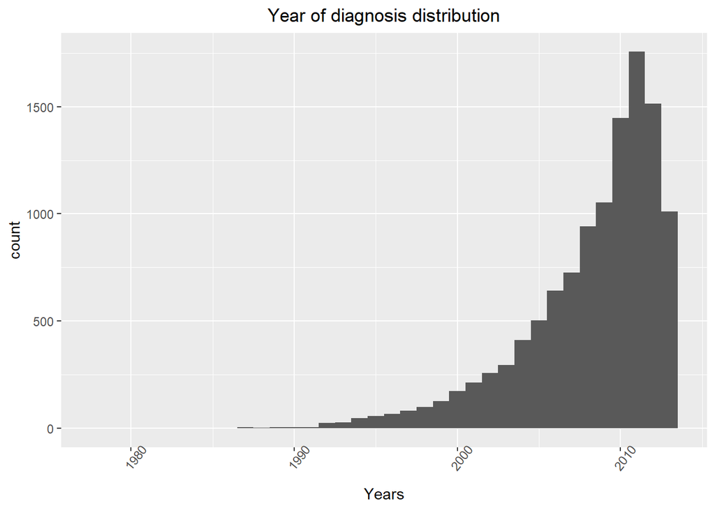

```r
ggplot(clinical_data_TCGA, aes(x=year_of_diagnosis, fill=year_of_diagnosis)) +
  geom_histogram(binwidth = 1) +
  labs(title="Year of diagnosis distribution", x = "Years") +
  theme(axis.text.x =element_text(angle = 50, hjust = 0.5),
        plot.title = element_text(hjust = 0.5), legend.position = "none") +
  scale_fill_manual(values = mycolors)
```

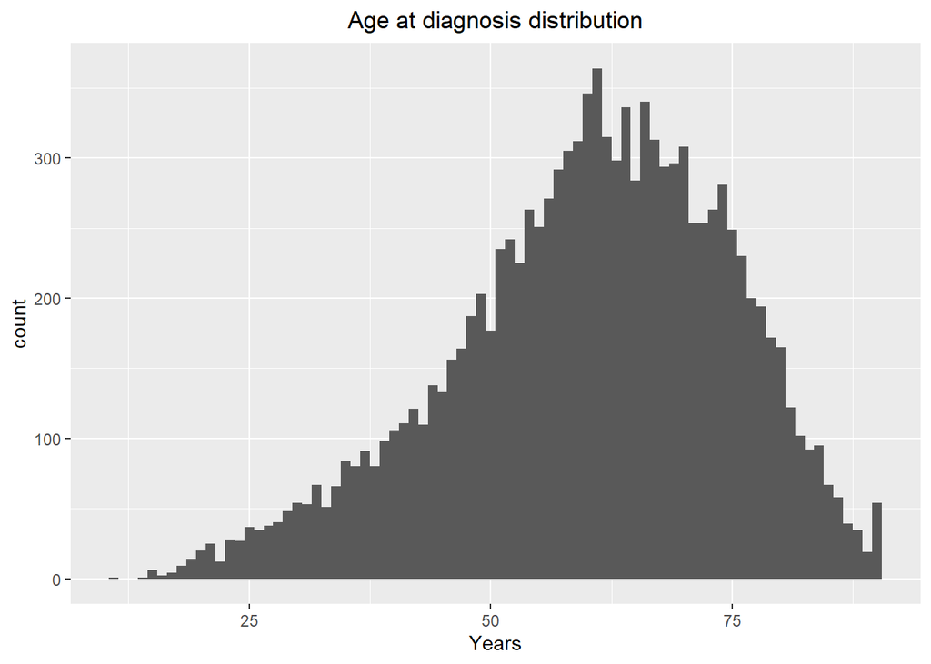

```r
ggplot(clinical_data_TCGA, aes(x=age_at_diagnosis)) +
  geom_histogram(binwidth = 1) +
  labs(title="Age at diagnosis distribution", x = "Years") +
  theme(plot.title = element_text(hjust = 0.5))
```

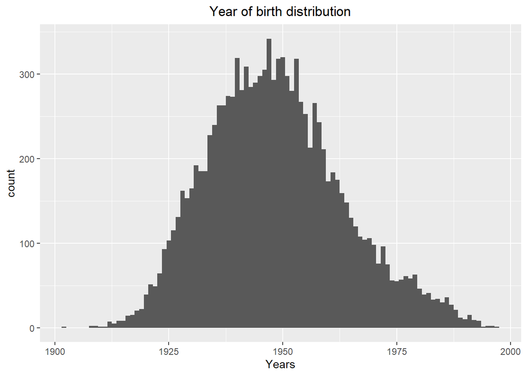

```r
ggplot(clinical_data_TCGA, aes(x=year_of_birth)) +
  geom_histogram(binwidth = 1) +
  labs(title="Year of birth distribution", x = "Years") +
  theme(plot.title = element_text(hjust = 0.5))
```

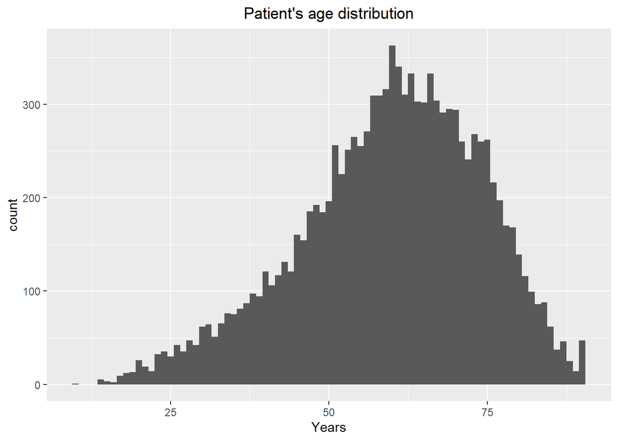

```r
ggplot(clinical_data_TCGA, aes(x=age_at_index)) +
  geom_histogram(binwidth = 1) +
  labs(title="Patient's age distribution", x = "Years") +
  theme(plot.title = element_text(hjust = 0.5))
```

Except from “Year of diagnosis distribution” seems to distribute normaly or a little incline to left or right.  
Year of diagnosis distribution has a long left tail.

Looking at categorical features to detect and manage missing data:

```r
round(prop.table(table(clinical_data_TCGA$
                         treatments_radiation_treatment_or_therapy))*100,
      digits = 1)
```

```
##
##           no not reported          yes
##         59.2          9.2         31.6
```

```r
round(prop.table(table(clinical_data_TCGA$vital_status))*100, digits = 1)
```

```
##
##        Alive         Dead Not Reported
##         66.8         33.1          0.1
```

```r
round(prop.table(table(clinical_data_TCGA$synchronous_malignancy))*100,
      digits = 1)
```

```
##
##           No Not Reported          Yes
##         81.4         18.2          0.4
```

```r
round(prop.table(table(clinical_data_TCGA$prior_malignancy))*100, digits = 1)
```

```
##
##           no not reported          yes
##         80.5          9.8          9.6
```

```r
round(prop.table(table(clinical_data_TCGA$prior_treatment))*100, digits = 1)
```

```
##
##           No Not Reported          Yes
##         98.6          0.0          1.3
```

```r
round(prop.table(table(clinical_data_TCGA$gender))*100, digits = 1)
```

```
##
##       female         male not reported
##         50.7         49.3          0.0
```

In order to avoid loosing more data i am substituting the not reported into no, and adding a column of not reported as: if yes: 1, 0 otherwise, in all columns with yes/no/not reported. and checking the percentage again.

```r
clinical_data_TCGA$treatments_radiation_treatment_or_therapy_not_reported <-
  ifelse(clinical_data_TCGA$
           treatments_radiation_treatment_or_therapy == "not reported", 1, 0)
clinical_data_TCGA$treatments_radiation_treatment_or_therapy[
  clinical_data_TCGA$
    treatments_radiation_treatment_or_therapy == "not reported"] <- "no"


#Since this is the predicting class i am not going to add a not reported column
clinical_data_TCGA$treatments_pharmaceutical_treatment_or_therapy[
  clinical_data_TCGA$
    treatments_pharmaceutical_treatment_or_therapy == "not reported"] <- "no"

clinical_data_TCGA$prior_malignancy_not_reported <-
  ifelse(clinical_data_TCGA$prior_malignancy == "not reported", 1, 0)
clinical_data_TCGA$
  prior_malignancy[clinical_data_TCGA$prior_malignancy ==
                     "not reported"] <- "no"

# since there are only 4 not reported,
#i will not add a "not reported column for this category,
#as all of it, except for 4 values will be zeros.
clinical_data_TCGA$prior_treatment[clinical_data_TCGA$
                                     prior_treatment == "Not Reported"] <- "no"

clinical_data_TCGA$vital_status_not_reported <-
  ifelse(clinical_data_TCGA$vital_status == "Not Reported", 1, 0)
clinical_data_TCGA$vital_status[clinical_data_TCGA$
                                  vital_status == "Not Reported"] <- "Dead"
```

```r
clinical_data_TCGA <-
  clinical_data_TCGA %>% dplyr::select(-synchronous_malignancy, -prior_treatment)

clinical_data_TCGA <- droplevels(clinical_data_TCGA)
```

```r
sum(is.na(clinical_data_TCGA))
```

```
## [1] 0
```

There is no more NA’s and missing data was managed.

I would like to predict whether the patient will have pharmaceutical treatment or therapy,  
If i could predict this feature, knowing if a patient will go through radiation or pharmaceutical treatment can help determine the best adjuvant therapy if needed and as soon as possible, even before the treatment beginning.  
Bellow is the percentage of this class to verify they are more or less even and the data is not inclined to one of them.  
And they are so i can move forward.

```r
round(prop.table(table(clinical_data_TCGA$
                         treatments_pharmaceutical_treatment_or_therapy))*100,
      digits = 1)
```

```
##
##   no  yes
## 57.7 42.3
```

### Narmalization and last preparations

Most of the data is categorical, therefore i will use one hot encoder from the “caret” package on these features.  
The fullRank option marked true allows redundant columns to be removed. for example- if the categorical data has only “yes”/“no” there will be one column created as yes and there will be 1 if the value was yes and 0 if the value was no.

```r
dummies_model <- dummyVars(treatments_pharmaceutical_treatment_or_therapy ~ .,
                           data=clinical_data_TCGA, fullRank=T)

Data_mat <- predict(dummies_model, newdata = clinical_data_TCGA)

clinical_data_TCGA_bin <- data.frame(Data_mat)
clinical_data_TCGA_bin$treatments_pharmaceutical_treatment_or_therapy <-
  clinical_data_TCGA$treatments_pharmaceutical_treatment_or_therapy
```

```r
sum(is.na(clinical_data_TCGA_bin))
```

```
## [1] 0
```

```r
clinical_data_TCGA_bin <- na.omit(clinical_data_TCGA_bin)
```

Normalize the numeric columns: year_of_diagnosis, age_at_diagnosis, year_of_birth, age_at_index for values between 0 and 1.

```r
#create the normalization function:
normalize <- function(x) {
return ((x - min(x)) / (max(x) - min(x)))
}
clinical_data_TCGA_bin$year_of_diagnosis <-
  normalize(as.numeric(clinical_data_TCGA_bin$year_of_diagnosis))
clinical_data_TCGA_bin$age_at_diagnosis <-
  normalize(as.numeric(clinical_data_TCGA_bin$age_at_diagnosis))
clinical_data_TCGA_bin$year_of_birth <-
  normalize(as.numeric(clinical_data_TCGA_bin$year_of_birth))
clinical_data_TCGA_bin$age_at_index <-
  normalize(as.numeric(clinical_data_TCGA_bin$age_at_index))

summary(c(clinical_data_TCGA_bin$year_of_diagnosis,
          clinical_data_TCGA_bin$age_at_diagnosis,
          clinical_data_TCGA_bin$year_of_birth,
          clinical_data_TCGA_bin$age_at_index))
```

```
##    Min. 1st Qu.  Median    Mean 3rd Qu.    Max.
##  0.0000  0.4947  0.6536  0.6494  0.8269  1.0000
```

```r
#move predicting column to be the first
clinical_data_TCGA_bin <- clinical_data_TCGA_bin %>%
  dplyr::select(treatments_pharmaceutical_treatment_or_therapy, everything())

skim(clinical_data_TCGA)
```

Data summary

| Name | clinical_data_TCGA |
| --- | --- |
| Number of rows | 11512 |
| Number of columns | 20 |
| _______________________ |  |
| Column type frequency: |  |
| factor | 11 |
| numeric | 9 |
| ________________________ |  |
| Group variables | None |

**Variable type: factor**

| skim_variable | n_missing | complete_rate | ordered | n_unique | top_counts |
| --- | --- | --- | --- | --- | --- |
| tissue_or_organ_of_origin | 0 | 1 | FALSE | 136 | Bre: 1070, Kid: 915, Bla: 669, Bra: 650 |
| prior_malignancy | 0 | 1 | FALSE | 2 | no: 10402, yes: 1110 |
| tumor_stage | 0 | 1 | FALSE | 20 | not: 3916, sta: 1271, sta: 971, sta: 883 |
| morphology | 0 | 1 | FALSE | 136 | 814: 1541, 807: 1152, 812: 984, 850: 926 |
| site_of_resection_or_biopsy | 0 | 1 | FALSE | 154 | Bre: 1070, Kid: 915, Bla: 669, Bra: 651 |
| primary_diagnosis | 0 | 1 | FALSE | 135 | Ade: 1541, Squ: 1152, Tra: 984, Inf: 926 |
| vital_status | 0 | 1 | FALSE | 2 | Ali: 7690, Dea: 3822 |
| gender | 0 | 1 | FALSE | 2 | fem: 5834, mal: 5678 |
| treatments_pharmaceutical_treatment_or_therapy | 0 | 1 | FALSE | 2 | no: 6637, yes: 4875 |
| treatments_radiation_treatment_or_therapy | 0 | 1 | FALSE | 2 | no: 7878, yes: 3634 |
| disease | 0 | 1 | FALSE | 32 | BLC: 1179, BRC: 1079, GBM: 596, OV: 576 |

**Variable type: numeric**

| skim_variable | n_missing | complete_rate | mean | sd | p0 | p25 | p50 | p75 | p100 | hist |
| --- | --- | --- | --- | --- | --- | --- | --- | --- | --- | --- |
| year_of_diagnosis | 0 | 1 | 2008.21 | 4.27 | 1978.00 | 2006.00 | 2009.00 | 2011.00 | 2013.00 | ▁▁▁▂▇ |
| age_at_diagnosis | 0 | 1 | 60.25 | 14.35 | 10.91 | 51.38 | 61.42 | 70.72 | 90.06 | ▁▂▆▇▃ |
| race | 0 | 1 | 0.76 | 0.42 | 0.00 | 1.00 | 1.00 | 1.00 | 1.00 | ▂▁▁▁▇ |
| year_of_birth | 0 | 1 | 1948.49 | 14.80 | 1902.00 | 1938.00 | 1947.00 | 1958.00 | 1997.00 | ▁▅▇▃▁ |
| age_at_index | 0 | 1 | 59.72 | 14.35 | 10.00 | 51.00 | 61.00 | 70.00 | 90.00 | ▁▂▆▇▃ |
| hispanic_or_latino | 0 | 1 | 0.24 | 0.42 | 0.00 | 0.00 | 0.00 | 0.00 | 1.00 | ▇▁▁▁▂ |
| treatments_radiation_treatment_or_therapy_not_reported | 0 | 1 | 0.09 | 0.29 | 0.00 | 0.00 | 0.00 | 0.00 | 1.00 | ▇▁▁▁▁ |
| prior_malignancy_not_reported | 0 | 1 | 0.10 | 0.30 | 0.00 | 0.00 | 0.00 | 0.00 | 1.00 | ▇▁▁▁▁ |
| vital_status_not_reported | 0 | 1 | 0.00 | 0.03 | 0.00 | 0.00 | 0.00 | 0.00 | 1.00 | ▇▁▁▁▁ |

### Dimensionality reduction:

### PCA

Looking for patterns in the whole data, by finding correlations between variables.  
PC1 and PC2 explain the highest variability in the data.

```r
pca <- prcomp(clinical_data_TCGA_bin[2:ncol(clinical_data_TCGA_bin)])
```

[figure not shown]

```r
library(factoextra)
# Changing the direction of the eigenvectors (they are negative by default)
pca$rotation <- - pca$rotation
pca$x <- - pca$x
str(pca)
biplot(pca, scale = 0)
# calculating variance of each PC by squared the std
VE <- pca$sdev^2
PVE <- VE / sum(VE)
round(PVE, 2)

#visualization of pca
fviz_pca_ind(pca, geom.ind = "point", pointshape = 21,
             pointsize = 2,
             fill.ind = clinical_data_TCGA_bin$
               treatments_pharmaceutical_treatment_or_therapy,
             col.ind = "black",
             palette = "jco",
             addEllipses = TRUE,
             label = "var",
             col.var = "black",
             repel = TRUE,
             legend.title = "Pharmaceutical/therapy") +
  ggtitle("2D PCA-plot TCGA clinical dataset") +
  theme(plot.title = element_text(hjust = 0.5))
```